# Breaking Into Data & AI

An Entry-Level Job Market & Skill-Gap Audit (n = 636 Full-Text Postings)

Pablo

2026-11-24

## The Problem & Analytical Pipeline

### Business Question

Aspiring data professionals face noisy job boards where “Entry-Level” searches return senior roles and truncated snippets hide real technical requirements.

- **4 Target Tracks:** Data Analyst, Data Scientist, ML Engineer, AI Engineer
- **Full-Text Quality Gate:** `LENGTH >= 1,000` chars (n = 636 deduplicated postings)
- **In-Scope Audit:** 188 verified Intern & Junior postings (29.6%)

### End-to-End Architecture

- **Multi-Source Ingestion (R):** Official Adzuna REST API + public ATS feeds (Greenhouse, Lever, Ashby, The Muse)
- **Warehousing (PostgreSQL 16):** Idempotent ingestion into `raw_jobs` inside Docker Compose
- **SQL Feature Engineering:** Deduplication, seniority filtering, and 16 POSIX regex (`~*`) skill flags
- **BI & Reporting:** Interactive Tableau Public dashboard + reproducible Quarto deliverables

## Finding 1: The Seniority Distortion Gap

**70.4%** (448 of 636) of non-senior search results actually require Senior/Lead titles or 4+ years of experience.

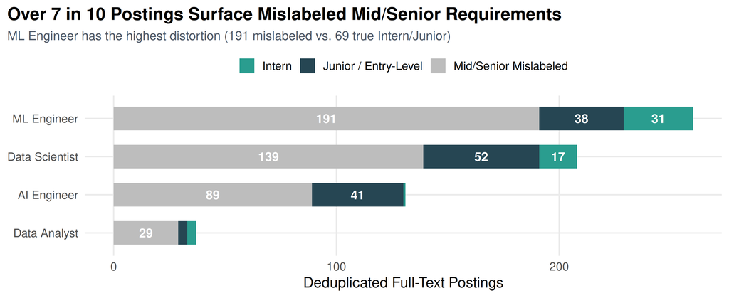

## Finding 2: Universal vs. Specialized Stacks

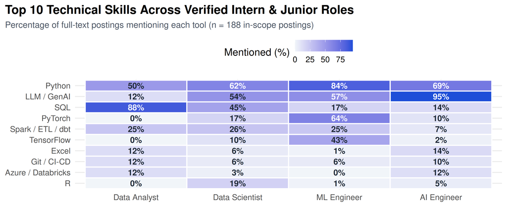

## Finding 3: Credential & Experience Barriers

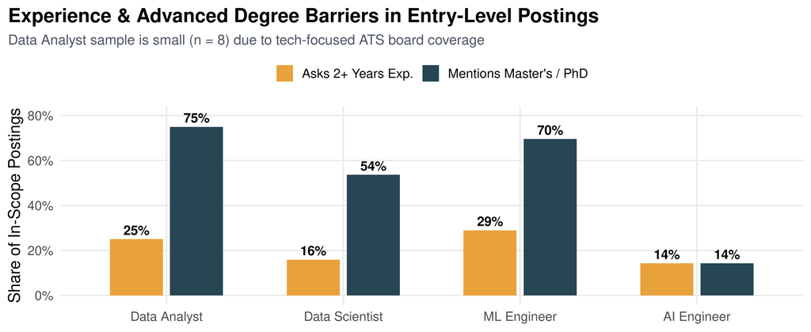

## Finding 4: Compensation & Work-Mode Flexibility

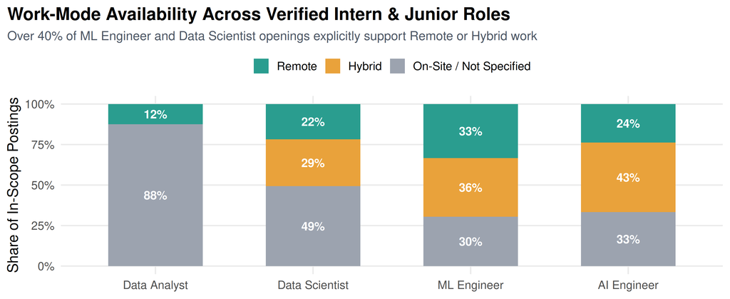

## Cross-Role Entry-Level Scorecard

Summary across all 188 verified Intern & Junior postings:

| Role | Postings | Explicit 0–1 Yr | Asks 2+ Yrs | Master’s / PhD | Remote / Hybrid | Disclosed Pay (n) | Median Salary |
| --- | --- | --- | --- | --- | --- | --- | --- |
| Data Analyst | 8 | 12% | 25% | 75% | 12% | 2 | $160,647 |
| Data Scientist | 69 | 3% | 16% | 54% | 51% | 13 | $440,000 |
| ML Engineer | 69 | 1% | 29% | 70% | 70% | 3 | $445,500 |
| AI Engineer | 42 | 2% | 14% | 14% | 67% | 7 | $202,500 |

*Note on small cells:* Disclosed salaries (n = 2 to 13 per role) and Data Analyst (n = 8) reflect coastal tech pay-transparency disclosures and ATS board coverage.

## Governance, Limitations & Project Links

### Data Governance & Caveats

- **Quality Gate Trade-Off:** Filtering `LENGTH >= 1,000` eliminated truncated Adzuna snippets for accurate regex skill detection, shifting sample weight toward tech/AI ATS boards (n = 8 Data Analyst caveat).
- **Pay-Transparency Skew:** Salary medians reflect employers disclosing pay under state transparency laws (CA, NY, WA).
- **Ethical & Reproducible:** 100% official public APIs/ATS feeds; reproducible via `docker compose up`.

### Explore the Deliverables

- **Interactive Dashboard:** Tableau Public (Entry-Level Data & AI Audit)
- **Full Technical Report:** `docs/case_study_report.html`
- **Source Code & SQL:** GitHub (`R/`, `sql/`, `docker/`)